# BF-1: Biodiversity

**Overview**

Compilation of **models, approaches and tools** that can be used to measure, monitor and evaluate multiple facets of biodiversity.

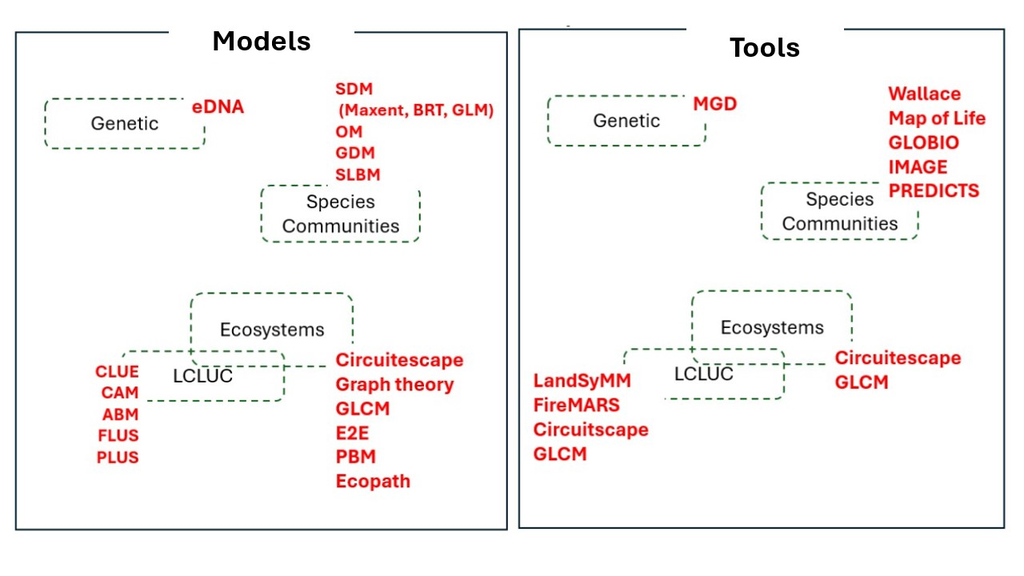

**Models**: AGM (Agent Based Models), CAM (Cellular Automata Model), , CLUE (Conversion of Land Use and its Effects), Circuitscape (connectivity), E2E (End to End Model), Ecopath (aquatic webs), eDNA (Environmental DNA), FLUS (Future Land Use Simulation model), GDM (Generalized Dissimilarity Model), GLCM (General Landscape Connectivity Model), Graph theory (connectivity), Maxent (Maximum Entropy), OM (Occupancy Model), PBM (Process-Based Model), PLUS (Patch-generating Land Use Simulation), SDM (Species Distribution Model), SLBM (Site Level Biodiversity metrics). **Tools**: Bon in a Box (GEO BON tools), FireMARS (Fire monitoring and reporting tool), GLCM (General Landscape Connectivity Model), GLOBIO (calculates the current state, trends and possible future scenarios), LandSyMM (Land system changes across scales), Marxant (solutions to conservation planning problems), MGD (Maps of genetic Diversity), PREDICTS (Projecting Responses of Ecological Diversity In Changing Terrestrial Systems).

**Genetics**

**Environmental DNA (eDNA)**

Monitoring the status and trends of genetic diversity using genetic indicators, multiple species relevant for local communities. and key to inform policy and report national and global targets (see [Hoban et al. (2023)](https://conbio.onlinelibrary.wiley.com/doi/full/10.1111/conl.12953) for implementation in other countries. Maps of genetic diversity for the HJBL would provide insight into adaptive potential ([Bishop et al. 2023](https://besjournals.onlinelibrary.wiley.com/doi/full/10.1111/2041-210X.14090?campaign=wolearlyview)).

**Assessment of Status**

Some Global and Canadian examples of model implementation.

| Models/Approaches | Have they been used? | In Canada? |
| --- | --- | --- |
| Environmental DNA (eDNA) | [Carraro et al. (2020)](https://www.nature.com/articles/s41467-020-17337-8) [Bani et al. (2020)](https://www.sciencedirect.com/science/article/pii/S0065250420300118?casa_token=uK81BQ96yJ0AAAAA:X92wzGY… | [Bernos et al. (2023)](https://cdnsciencepub.com/doi/full/10.1139/cjfas-2022-0162) [Darshini (2016)](https://scholar.uwindsor.ca/cgi/viewcontent.cgi?article=6720&context=etd) |

**Indicators**

Monitoring the status and trends of genetic diversity using genetic indicators, multiple species relevant for local communities are key to inform policy and report national and global targets (see [Hoban et al. (2023)](https://conbio.onlinelibrary.wiley.com/doi/full/10.1111/conl.12953)

**Assessment of Status**

Some Global and Canadian examples of model implementation and tools available and their supporting organization.

| Models/ Approaches | Have they been used? | In Canada? |
| --- | --- | --- |
| Genetic diversity indicators | [Hoban et al. (2022)](https://conbio.onlinelibrary.wiley.com/doi/epdf/10.1111/conl.12953) |  |

**Genetic network and connectivity**

**Assessment of Status**

Some Global and Canadian examples of model implementation.

| Models/ Approaches | Have they been used? | In Canada? |
| --- | --- | --- |
| Genetic network and connectivity |  | [Fourmnier et al. (2024)](https://www.biorxiv.org/content/biorxiv/early/2024/01/25/2024.01.22.576731.full.pdf) |

**Species**

**Species Distribution Models (SDMs)**

Most questions focused on the shifting distribution of biodiversity cannot be answered experimentally, because many important environmental drivers and biological constraints operate at large spatiotemporal scales.

Models for biodiversity can describe geographic patterns in the distribution of individual species and the spatial turnover in the composition of multiple species. Species Distribution Models (SDMs) are statistical, correlating spatial distribution (occurrence or abundance data across locations) with environmental and geographic variables (spatial environmental data) describing those locations (see [Elith & Leathwick 2009](https://www.annualreviews.org/doi/full/10.1146/annurev.ecolsys.110308.120159), for a review). SDMs use spatial environmental data to make inferences about species’ range limits and habitat suitability; conceptually they are mapping components of the species’ ecological niche through space and time. These models now hold a prominent place within biodiversity science because computing facilities now allow easy use of spatial data layers (GIS software) and remote sensing products that describe geographic environmental structure can be combined with large data sets of species occupancy (e.g. obtained from the Global Biodiversity Information Facility).

An SDM model can be used to predict the species’ distribution across a large geographic extent under different scenarios of environmental (e.g., climate) change. They are widely used in conservation assessments comparing species distributions under different scenarios both in target-seeking and exploratory scenarios (see Scenarios section).

SDMs have been implemented for multiple purposes including assessing prioritization scenarios to protect biodiversity ([Berteaux et al. 2018](https://www.nature.com/articles/s41598-018-23050-w), [Eckert et al. 2023](https://www.biorxiv.org/content/10.1101/2022.12.16.520787v1.full)), linking local to regional conservation ([Albert et al. 2017](https://mvellend.recherche.usherbrooke.ca/2017_ConsBiol_Albert_etal.pdf), [DeLuca et al. 2023](https://conbio.onlinelibrary.wiley.com/doi/full/10.1111/csp2.12975)), biological invasions ([Lezner et al. 2019](https://academic.oup.com/bioscience/article/69/9/697/5532759?login=false)), impacts on ecosystems and human well-being ([Pecl et al. 2017](https://www.science.org/doi/full/10.1126/science.aai9214)) and evaluating critical habitat for species at risk ([Leston et al. 2023](https://link.springer.com/article/10.1007/s10531-023-02761-1)), linking biodiversity and ecosystems function (Antunes et al. 2024), among many others.

Multiple studies have identified climate refugia ([Michalak et al. 2018](https://conbio.onlinelibrary.wiley.com/doi/full/10.1111/cobi.13130)) under multiple climatic scenarios ([Stralberg et al. 2018](https://onlinelibrary.wiley.com/doi/full/10.1111/ddi.12356), [AdaptWEST](https://adaptwest.databasin.org/pages/climate-resilience-data-explorer/)) for various taxonomic groups in North America ([Stralberg et al. 2017](https://ace-lab.ca/assets_b/Stralberg_et_al-2018-Global_Ecology_and_Biogeography.pdf)). Conservation strategies ([Belote et al. 2017](https://academic.oup.com/bioscience/article/67/6/494/3102936?login=false), [Ranius et al. 2023](https://link.springer.com/article/10.1007/s13280-022-01779-z)) to inform conservation planning ([Carroll et al. 2017](https://onlinelibrary.wiley.com/doi/10.1111/gcb.13679), [Stralberg et al. 2020](https://conbio.onlinelibrary.wiley.com/doi/full/10.1111/conl.12712), [Stralberg et al. 2020](https://esajournals.onlinelibrary.wiley.com/doi/10.1002/fee.2188), [Droboski et al. 2021](https://www.nature.com/articles/s43247-021-00270-z)) and the implications for costs and configuration of protecting areas ([Lawler et al. 2020](https://royalsocietypublishing.org/doi/full/10.1098/rstb.2019.0117)) under climate change scenarios have been also evaluated.

[Stralberg et al. (2020)](https://conbio.onlinelibrary.wiley.com/doi/full/10.1111/conl.12712) developed a conservation ranking map for North America to identify priority areas, including climatic macro-refugia for trees and birds (e.g., [Stralberg et al. 2018](https://ace-lab.ca/assets_b/Stralberg_et_al-2018-Global_Ecology_and_Biogeography.pdf)), microrefugia (using environmental heterogeneity surrogates, that is topography, e.g., [Ackerly et al. 2010](https://onlinelibrary.wiley.com/doi/full/10.1111/j.1472-4642.2010.00654.x)) and climatic corridors ([Carroll et al. 2018](https://onlinelibrary.wiley.com/doi/full/10.1111/gcb.14373), [Anderson et al. 2023](https://www.pnas.org/doi/10.1073/pnas.2204434119)). [Buenafe et al. (2023)](https://esajournals.onlinelibrary.wiley.com/doi/full/10.1002/eap.2852) applied a climate-smart conservation planning framework that prioritizes the protection of climate refugia.

**Assessment of Status**

Some Global and Canadian examples of model implementation.

| Models/ Approaches | Have they been used? | In Canada? |
| --- | --- | --- |
| SDMs - Maxent | [Gerstner et al. (2024)](https://royalsocietypublishing.org/doi/full/10.1098/rsta.2023.0057) [Galante et al. (2022)](https://conbio.onlinelibrary.wiley.com/doi/full/10.1111/csp2.12863) | [Arce et al. (2023)](https://biab2.geobon.org/viewer/SHI_pipeline%3E991b12792ae29500d2defb194aba60d6) |
| SDMs - Generalized Linear Models | [Newbold (2018)](https://royalsocietypublishing.org/doi/full/10.1098/rspb.2018.0792) |  |
| SDMs - Boosted regression trees | [Manley et al . (2023)](https://pubmed.ncbi.nlm.nih.gov/36993623/) [Newbold (2018)](https://royalsocietypublishing.org/doi/full/10.1098/rspb.2018.0792) | [Stralberg et al. (2015)](https://onlinelibrary.wiley.com/doi/full/10.1111/ddi.12356) |
| Spatial Bayesian SDMs | [Redding et al. (2017)](https://pubmed.ncbi.nlm.nih.gov/29190296/) [Weithase et al. (2024)](https://onlinelibrary.wiley.com/doi/full/10.1111/geb.13819?campaign=woletoc) [Kralicek et al. (2022)](https:… | [Adde et al. (2020)](https://onlinelibrary.wiley.com/doi/full/10.1111/ddi.13129) |

**Occupancy Models (OMs)**

Occupancy Models (OMs) are used to account for imperfect detection of organisms in surveys and to determine the probability of the true presence or absence of a species at a site. “They do so by modeling the probability that a species occupying a site is detected, often including environmental covariates to explain variation in detectability among sites (MacKenzie et al., 2002)” ([Stewart et al. 2022](https://esajournals.onlinelibrary.wiley.com/doi/full/10.1002/ecy.3942?campaign=woletoc)). They can be used to model single ([Gould et al. 2019](https://usgs-cru-individual-data.s3.amazonaws.com/jwcain/intellcont/Gould%20et%20al.%20BioCon%202019-1.pdf)) and multi-species occupancy ( [Devarajan et al. 2020](https://onlinelibrary.wiley.com/doi/full/10.1111/ecog.04957)). And, OMs have shown some potential of conservation prioritization (e.g., [Calderón et al. 2022](https://zslpublications.onlinelibrary.wiley.com/doi/10.1111/acv.12772)).

**Assessment of Status**

Some Global and Canadian examples of model implementation.

| Models/ Approaches | Have they been used? | In Canada? |
| --- | --- | --- |
| Occupancy Models (OMs) | [Gould et al. (2019)](https://usgs-cru-individual-data.s3.amazonaws.com/jwcain/intellcont/Gould%20et%20al.%20BioCon%202019-1.pdf)**,** MacKenzie et al. (2002), [Calderón et al. 2022](https://zslpublic… | [Tozer et al. (2020)](https://wildlife.onlinelibrary.wiley.com/doi/abs/10.1002/jwmg.21840?casa_token=StdpjpGDVLoAAAAA:oIZ3xxuTvpURTzRWGrdTBaAPjevXPY5Fpqd_5gmucZgzXWnRX16rF8NQDhbMV-hDJPEw0Nixbo85ZqEj),… |

**Species Trait Models (STMs)**

The principles of biophysical ecology can be used to link spatial data to the physiological responses and constraints of organisms. This provides a mechanistic view of the fundamental niche which can then be mapped to the landscape to infer range constraints” ([Kearney & Porter 2009](https://onlinelibrary.wiley.com/doi/epdf/10.1111/j.1461-0248.2008.01277.x)).

**Statistical models of local biodiversity change**

Generalized Linear mixed effect models are used to explain variation in a measure of diversity, such as species richness, or biodiversity intactness across sites varying in human land use ([Newbold et al. 2015](https://www.nature.com/articles/nature14324)). Multiple studies have applied this approach using site species composition data obtained from the Projecting Responses of Ecological Diversity In Changing Terrestrial Systems ([PREDICTS](https://www.nhm.ac.uk/our-science/research/projects/predicts.html)) database. This work repeatedly finds average declines in local diversity, relative abundance and functional group diversity due to human pressures (land use intensity, human density) on land cover ([Newbold et al. 2015](https://www.nature.com/articles/nature14324), [2016](https://www.science.org/doi/10.1126/science.aaf2201)). Similar approach was applied to assess the impact of human pressures on genetic diversity ([Millette et al. 2019](https://onlinelibrary.wiley.com/doi/abs/10.1111/ele.13394)).

**Assessment of Status**

Some Global and Canadian examples of model implementation.

| Models/ Approaches | Have they been used? | In Canada? |
| --- | --- | --- |
| Site-level biodiversity metrics (e.g., species richness) | [Newbold et al. (2015)](https://www.nature.com/articles/nature14324)**,** [Daru et al. (2021)](https://www.nature.com/articles/s41467-021-27186-8), [Vilmi et al. (2016)](https://cdnsciencepub.com/doi/… | Kenchington et al. (2011) |

**Generalized Dissimilarity Models (GDMs)**

This class of models analyze and predict spatial patterns of turnover in community composition (beta diversity) across large regions ([Ferrier et al. 2007](https://onlinelibrary.wiley.com/doi/10.1111/j.1472-4642.2007.00341.x)). They have been used for multiple purposes from identifying the potential impact of climate change on composition across Australia ([Ferrier et al. 2012](https://research.csiro.au/climate/wp-content/uploads/sites/54/2016/03/13E_CAF-Working-Paper-13E.pdf)) to evaluating future scenarios of LCLUC and Climate Change ([Di Marco et al. 2019](https://onlinelibrary.wiley.com/doi/10.1111/gcb.14663)), identifying high-value biodiversity habitat ([Mokany et al. 2020](https://www.pnas.org/doi/10.1073/pnas.1918373117)), creating biodiversity surrogates for conservation assessment ([Ware et al. 2018](https://onlinelibrary.wiley.com/doi/full/10.1111/ddi.12766)), and biodiversity analysis and conservation ([Mokany et al. 2022](https://onlinelibrary.wiley.com/doi/full/10.1111/geb.13459)), among many others. Additional approaches to assess patterns and drivers of beta diversity at different spatial scales have been proposed (see [He et al. 2023](https://nsojournals.onlinelibrary.wiley.com/doi/10.1111/ecog.06901)). General dissimilarity models go beyond single species and predict community-level features such as community composition and species turnover or richness ([Ferrier & Guisan 2006](https://besjournals.onlinelibrary.wiley.com/doi/full/10.1111/j.1365-2664.2006.01149.x)).

**Assessment of Status**

Some Global and Canadian examples of model implementation.

| Models/ Approaches | Have they been used? | In Canada? |
| --- | --- | --- |
| Generalized Dissimilarity Models (GDMs) | [Ferrier et al. (2007)](https://onlinelibrary.wiley.com/doi/10.1111/j.1472-4642.2007.00341.x), [Rosauer et al. (2013)](https://nsojournals.onlinelibrary.wiley.com/doi/abs/10.1111/j.1600-0587.2013.0046… | [Garner et al. (2022)](https://www.ncbi.nlm.nih.gov/pmc/articles/PMC9426515/) |

**Assessments**

**Assessment of Status**

Some Global and Canadian examples of model implementation.

| Models/ Approaches | Have they been used? | In Canada? |
| --- | --- | --- |
| Integrative Assessment Models (IAMs) | [Schipper et al. (2019)](https://onlinelibrary.wiley.com/doi/10.1111/gcb.14848) [Janse et al. (2015)](https://www.sciencedirect.com/science/article/pii/S1462901114002354?via%3Dihub) [Kuiper et al. (20… |  |
| Integrative Assessment Models (IAMs) | [Purvis et al. (2018)](https://www.sciencedirect.com/science/article/abs/pii/S0065250417300284?via%3Dihub) [Millard et al. (2021)](https://www.nature.com/articles/s41467-021-23228-3), [Newbold (2018)]… |  |
| [Species Threat Abatement and Restoration](https://www.iucn.org/resources/conservation-tool/species-threat-abatement-and-restoration-star-metric) |  | [Mair et al. (2021)](https://hal.science/hal-03417602/document) |

**Ecosystems**

**Global Vegetation Models**

These are equilibrium process-based models that simulate the potential distribution of generalised types of natural vegetation on the basis of the physiological properties of plant groups, average seasonal climate and hydrological conditions and the direct physiological effects of elevated atmospheric carbon dioxide (i.e., increased water-use efficiency by plants). Like Global Climate Models, GVMs are used to understand how climate change will drive changes in the distribution of major plant taxa (e.g., boreal, temperate and tropical forests, grasslands, shrubland, tundra).

[Leemieux & Scott (2005)](https://onlinelibrary.wiley.com/doi/abs/10.1111/j.0008-3658.2005.00103.x) used two GVMs models, BIOME3 ([Haxeltine & Prentice 1996](https://agupubs.onlinelibrary.wiley.com/doi/10.1029/96GB02344)) and Mapped Atmosphere Plant Soil System (MAPSS) ([Neilson 1995](https://esajournals.onlinelibrary.wiley.com/doi/10.2307/1942028)) to project the future equilibrium outcome of vegetation across Canada’s protected area network at the time. They found over 40 percent of Canada’s protected areas are projected to experience a change in biome type as a result of climate change, the results of this study contribute to a growing body of research that questions the capacity of existing protected area networks to fulfil this objective in an era of global climate change

**Land cover and land use changes models**

An array of spatially explicit models has been developed to simulate and predict the possible future outcomes of land cover and land use changes. For instance, the [CLUE model](https://www.environmentalgeography.nl/site/data-models/data/clue-model/) is a dynamic, spatially explicit, land cover and land use change model used in multiple applications such as deforestation, land degradation, urbanization, land abandonment and integrated assessment of land cover change and urban growth ([Zhou et al. 2016](https://www.mdpi.com/2071-1050/8/11/1182)), among others. For the conversion of land use and its effects at a small region extent the CLUE-S model has been developed ([Gao et al. 2021](https://www.sciencedirect.com/science/article/abs/pii/S0301420721000167)). The Dyna CLUE integrates demand-driven changes in land area with locally determined conversion processes ([Verburg & Overmars, 2009](https://link.springer.com/article/10.1007/s10980-009-9355-7)).

Cellular Automata Markov simulation models have been also used to quantitatively simulate and predict land use change [(Kang et al. 2019](https://www.mdpi.com/2220-9964/8/10/454), [Beroho et al. 2023](https://www.mdpi.com/2072-4292/15/4/1162), [Leta et al. 2021](https://www.mdpi.com/2071-1050/13/7/3740),[Kang et al. 2019](https://www.mdpi.com/2220-9964/8/10/454), [Lu et al. 2019](https://link.springer.com/article/10.1007/s10661-019-7200-2), [Debnath et al. 2023](https://link.springer.com/article/10.1007/s40808-023-01713-6), [Zhang & Li 2013](https://www.tandfonline.com/doi/abs/10.2747/1548-1603.42.1.1)).

More sophisticated models like Future Land Use Simulation model (FLUS, [Li et al. 2017](http://www.geosimulation.cn/Papers/2017LUP-FLUS.pdf),; [Zhang et al. 2020](https://www.sciencedirect.com/science/article/abs/pii/S1470160X20307792)) simulate multiple land use scenarios; and the GMOP-PLUS model which analyzes changes in ecological and economic benefits and carbon emissions by optimizing the quantitative structure and spatial layout of land use in different scenarios ([Meng et al. 2023)](https://www.mdpi.com/2071-1050/15/5/3977).

Combining models and their strengths are also usual, for instance Multi-Objective Programming (MOP) is a top-down approach that can solve problems with conflict objectives, however it is not spatially explicit, so it has to be coupled with other models such as, for instance the Dynamic Conversion of Land Use and its Effect (Dyna, [Wang et al. 2018](https://www.sciencedirect.com/science/article/abs/pii/S1470160X18304886)).

Methods to downscaling global land use have also been developed ([West et al. 2014](https://iopscience.iop.org/article/10.1088/1748-9326/9/6/064004/meta), [Yourek et al. 2023](https://www.frontiersin.org/articles/10.3389/fenvs.2023.1055771/full)) to fit in Integrative Assessment Models (IAMs, [Pereira et al. 2010](https://citeseerx.ist.psu.edu/document?repid=rep1&type=pdf&doi=334fe605361ab3b2562bb022fe41f45ef8a4d7a1), [Harfoot et al. 2013](https://onlinelibrary.wiley.com/doi/10.1111/geb.12100)).

Harmonized sets of past and present land cover and land use methods are needed to simulate future scenarios ([Hurt et al. 2006](https://onlinelibrary.wiley.com/doi/abs/10.1111/j.1365-2486.2006.01150.x), [Hurt et al. 2011](https://link.springer.com/article/10.1007/s10584-011-0153-2)). Assessing uncertainties in LCLUC projections ([Prestele et al. 2016](https://pure.sruc.ac.uk/ws/portalfiles/portal/15258661/14440.pdf)) is also fundamental for monitoring biodiversity and ecosystem change.

Some models ([CLIMATESAVE Integrated Assessment Platform](https://climate-adapt.eea.europa.eu/en/metadata/tools/climsave-integrated-assessment-ia-platform), [GLOBIO](https://models.pbl.nl/image/index.php/GLOBIO_model)) are used to evaluate multiple drivers of change (LCLUC and CC) that might affect biodiversity and ecosystem services ([Veerkamp et al. 2020](https://link.springer.com/article/10.1007/s10113-020-01685-8)).

**Assessment of Status**

Some Global and Canadian examples of model implementation.

| Models/Approaches | Have they been used? | In Canada? |
| --- | --- | --- |
| Conversion of Land Use and its Effects [CLUE model](https://www.environmentalgeography.nl/site/data-models/data/clue-model/) | CLUE-s: [Zhou et al. (2016)](https://www.mdpi.com/2071-1050/8/11/1182), [Gao et al. (2021)](https://www.sciencedirect.com/science/article/abs/pii/S0301420721000167) Dyna CLUE: [Verburg and Overmars (2… | [Rakotoarinia et al. (2023)](https://link.springer.com/article/10.1007/s10661-023-11394-4) [El-Khoury et al. (2014)](https://onlinelibrary.wiley.com/doi/full/10.1111/cag.12105) |
| Cellular Automata Markov simulation models | [Kang et al. (2019)](https://www.mdpi.com/2220-9964/8/10/454), [Beroho et al. (2023)](https://www.mdpi.com/2072-4292/15/4/1162), [Leta et al. (2021)](https://www.mdpi.com/2071-1050/13/7/3740), [Kang e… | [Wang (2012)](https://prism.ucalgary.ca/server/api/core/bitstreams/f619ce49-31ed-49ae-9fb7-1679c4e2eb14/content) |
| Agent-based models | [Matthews et al. (2007)](https://link.springer.com/article/10.1007/s10980-007-9135-1), [Bartkowski et al (2020)](https://www.frontiersin.org/articles/10.3389/fenvs.2020.00103/full) | [McLane et al. (2011)](https://www.sciencedirect.com/science/article/abs/pii/S0304380011000524) [Freeman et al. (2009)](https://onlinelibrary.wiley.com/doi/abs/10.1111/j.1744-7976.2009.01169.x) |
| Future Land Use Simulation model (FLUS) | [Li et al. (2017)](http://www.geosimulation.cn/Papers/2017LUP-FLUS.pdf) [Cuellar & Perez (2023)](https://www.nature.com/articles/s41598-023-36600-8) [Zhang et al. (2020)](https://www.sciencedirect.com… | [Xu et al. (2022)](https://www.tandfonline.com/doi/full/10.1080/10095020.2022.2043730) |
| Patch-generating land use simulation (PLUS) | [Liang et al. (2021)](https://www.sciencedirect.com/science/article/abs/pii/S0198971520303021) [Meng et al. (2023)](https://www.mdpi.com/2071-1050/15/5/3977) [Mutale & Qiang (2024)](https://www.fronti… |  |
| Multi-Objective Programming (MOP) model | [Shi et al. (2023)](https://www.sciencedirect.com/science/article/pii/S2210670723001890?casa_token=BiUdtkmEcKEAAAAA:DH2dlww9K64wM1bxRbaB0ttPjpYKOMbJHOXEFFf1at0jhIJFiFPimvwUrmWgYmbUqsV1NrQ7Wz0) |  |
| MOP and Dyna | [Wang et al. (2018)](https://www.sciencedirect.com/science/article/abs/pii/S1470160X18304886) |  |
| Global models use land cover classes to estimate both past and current changes. | [Hurtt et al. (2011)](https://link.springer.com/article/10.1007/s10584-011-0153-2), [Winkler et al. (2021)](https://www.nature.com/articles/s41467-021-22702-2) |  |
| Future land use changes under multiple Climate SSPs and RCPs scenarios. | [Chen et al. (2020)](https://www.nature.com/articles/s41597-020-00669-x) |  |
| [LANDIS](https://www.landis-ii.org/) Forest landscape Model |  |  |
| Integrating LU & IAMs | [Hasegawa et al. (2017)](https://www.sciencedirect.com/science/article/pii/S0048969716327097#bb0120) |  |
| [GLOBIOM](https://iiasa.github.io/GLOBIOM/introduction.html) | [Soterroni et al. (2022)](https://www.researchgate.net/publication/365079983_Nature-Based_Solutions_Are_Critical_for_Putting_Brazil_on_Track_Towards_Net_Zero) |  |
| CAPS | [Meiyappan et al. (2014)](https://www.sciencedirect.com/science/article/pii/S0304380014003640) |  |
| CLUMondo | [van Asselen & Verburg (2013)](https://onlinelibrary.wiley.com/doi/abs/10.1111/gcb.12331) |  |
| Global Change Analysis Model [GCAM](https://gcims.pnnl.gov/modeling/gcam-global-change-analysis-model) |  |  |
| GLM | [Hurt et al. (2006)](https://onlinelibrary.wiley.com/doi/abs/10.1111/j.1365-2486.2006.01150.x) |  |
| IMAGE | [Letourneau et al. (2012)](https://www.sciencedirect.com/science/article/abs/pii/S136481521200014X) [Sleeter et al. (2012)](https://www.sciencedirect.com/science/article/pii/S0959378012000325) |  |
| LandSHIFT | [Schaldach et al. (2011)](https://www.sciencedirect.com/science/article/abs/pii/S1364815211000570) |  |
| [MagPIE](https://www.pik-potsdam.de/en/institute/departments/activities/land-use-modelling/magpie) | [Lotze-Campen et al. (2010)](https://www.sciencedirect.com/science/article/abs/pii/S0304380009006395) |  |
|  | [Awais et al. (2023)](https://egusphere.copernicus.org/preprints/2023/egusphere-2023-258/) [Krey et al. (2020)](https://pure.iiasa.ac.at/id/eprint/17115/) [Fricko et al. (2017)](https://www.sciencedir… |  |

**End-to-end ecosystem models (E2E)**

These models include multiple biophysical, social and economic components and the full cycle of processes to predict changes in the state of ecosystems in response to multiple drivers and management scenarios (e.g., [Cuddington et al. 2013](https://esajournals.onlinelibrary.wiley.com/doi/10.1890/ES12-00178.1)). [Rose et al. 2012](https://scientiamarina.revistas.csic.es/index.php/scientiamarina/article/view/1330) describe E2E as follow “(1) aims to represent the entire food web (including multiple species or functional groups at each of the key trophic levels as well as top predators in the system) and the associated abiotic environment; (2) requires the integration of physical and biological processes at different scales; (3) implements two-way interaction between ecosystem components; and (4) accounts for the dynamic forcing effect of climate and human impacts at multiple trophic levels.” Some examples include [ATLANTIS](https://research.csiro.au/atlantis/home/about-atlantis/) (for marine ecosystems,[Audzijonyte et al. 2019](https://besjournals.onlinelibrary.wiley.com/doi/full/10.1111/2041-210X.13272)) and for coastal regions ([Mutsert et al. 2021](https://www.frontiersin.org/articles/10.3389/fmars.2021.624532/full)).

**Assessment of Status**

Some Global and Canadian examples of model implementation.

| Models/Approaches | Have they been used? | In Canada? |
| --- | --- | --- |
| End-to-end ecosystem models (E2E) | [Rose et al. (2012)](https://scientiamarina.revistas.csic.es/index.php/scientiamarina/article/view/1330) [ATLANTIS](https://research.csiro.au/atlantis/home/about-atlantis/)**,** [Audzijonyte et al. (2… |  |

**Process-based models**

“Process-based models, which explicitly parameterize peatland hydrological, thermal, and biogeochemical processes, can account for the complex interactions among factors that are important in driving the dynamics of peatland ecosystems (e.g., temperature, soil moisture, vegetation type, thaw depth, CO2 fertilization). They are useful tools to explore responses of peatlands to future climate changes” (Qiu et al. 2022, e.g., 3-PG: [Adaptation of Asia Pacific forest to climate change](https://asiapacific.forestry.ubc.ca/research-approaches/ecological-models/process-based-ecological-models/)). They were developed to address some research gaps of carbon balance models. Qiu et al. (2022) highlighted three gaps:

- Standardized the use of similar critical inputs to draw robust conclusions from simulations.
- Include the contribution of different greenhouse gasses (GHGs such as CO2 and methane) to understand the influence of peatlands on global carbon cycle and climate change.
- Use a large time scale to understand the peatland response to warming.

**Assessment of Status**

Some Global and Canadian examples of model implementation.

| Models/Approaches | Have they been used? | In Canada? |
| --- | --- | --- |
| Process-based models | ORCHIDEE-PEAT ([Qiu et al. 2018](https://gmd.copernicus.org/articles/11/497/2018/), [Qiu et al. 2019](https://gmd.copernicus.org/articles/12/2961/2019/), [Qiu et al. 2020](https://onlinelibrary.wiley.… |  |

**Aquatic-food webs**

In construction!

**Assessment of Status**

Some Global and Canadian examples of model implementation.

| Models/Approaches | Have they been used? | In Canada? |
| --- | --- | --- |
| Aquatic food webs | [Ecopath with Ecosim (EwE)](https://ecopath.org/about/#toggle-id-3-closed), [Steenbeek et al. (2015)](https://kakearney.github.io/assets/pubs/Steenbeek2015.pdf). Applied in fisheries: Craig & Link 202… |  |

**Connectivity**

**In construction!**

**Assessment of Status**

Some Global and Canadian examples of model implementation.

| Models/ Approaches | Have they been used? | In Canada? |
| --- | --- | --- |
| Circuit approaches | [Hall et al. (2020)](https://www.mdpi.com/2073-445X/10/3/301) [Keely et al. (2022)](https://academic.oup.com/bioscience/article/72/4/372/6510171?guestAccessKey=69d7ad78-bca0-4e41-9700-17af5e6b7169&log… | [Pither et al . (2023)](https://journals.plos.org/plosone/article?id=10.1371/journal.pone.0281980#pone.0281980.ref057), [Pelletier et al. (2017)](https://journals.plos.org/plosone/article?id=10.1371/j… |
| Graph approaches | [Drielsma et al. (2022)](https://www.sciencedirect.com/science/article/pii/S0304380021003963) |  |

**Tools**

| Biodviersity facet | Purpose | Tools | Supporting Organization |
| --- | --- | --- | --- |
| **Genetic** | Genetic indicators | [Bon in a Box](https://boninabox.geobon.org/) | [GEO BON](https://geobon.org/), Montreal Canada |
|  | Generating continuous maps of genetic diversity | R Package [WINGEN](https://github.com/AnushaPB/wingen) [Bishop et al. (2023)](https://besjournals.onlinelibrary.wiley.com/doi/full/10.1111/2041-210X.14090?campaign=wolearlyview) | [Wang Lab](https://nature.berkeley.edu/wanglab/), University of California |
|  |  | R package (algatr) A Landscape Genomic Analysis Toolkit in [Chambers et al. (2023)](https://onlinelibrary.wiley.com/doi/full/10.1111/1755-0998.13884) | [Wang Lab](https://nature.berkeley.edu/wanglab/), University of California |
|  | Graphical displays of gentic clusters | [TESS](http://membres-timc.imag.fr/Olivier.Francois/tess.html) Spatial ancestry estimation program TESS [Caye et al. (2015)](https://onlinelibrary.wiley.com/doi/full/10.1111/1755-0998.12471?casa_token… | [The TIMC lab](http://membres-timc.imag.fr/Olivier.Francois/index.html), France |
| **Species** | Species Dsitribution Models (SDMs) | [Wallace](https://wallaceecomod.github.io/) | [Wallace Ecological Modeling App](https://github.com/wallaceEcoMod) |
|  |  | [Bon in a Box](https://boninabox.geobon.org/) | [GEO BON](https://geobon.org/), Montreal Canada |
|  |  | [Map of Life](https://mol.org/) | [Jetz Lab](https://jetzlab.yale.edu/), Yale University |
|  | Assessment | [GLOBIO](https://www.globio.info/what-is-globio) (species and aquatic) under [IMAGE](https://models.pbl.nl/image/index.php/Welcome_to_IMAGE_3.2_Documentation) framework State, trends and possible futu… | [PBL Netherlands Environmental Assessment Agency](https://www.pbl.nl/en) |
|  |  | [PREDICTS](https://www.nhm.ac.uk/our-science/research/projects/predicts.html) Statistical models of local biodiversity change | [The Natural History Museum](https://www.nhm.ac.uk/our-science/research/projects/predicts.html), London, UK |
| **Ecosystems** | Connectivity | [Linkage Mapper](https://linkagemapper.org/) Regional wildlife habitat connectivity analyses. | [Linkage Mapper](https://linkagemapper.org/) |
|  | Assessment | [MESSAGEix-GLOBIOM](https://docs.messageix.org/projects/global/en/latest/) Global model, covering 11 world regions and was originally developed for the quantification of the so-called Shared Socio-eco… | International Institute for Applied Systems Analysis ([IIASA](https://iiasa.ac.at/)), Laxenburg, Austria. |
|  | Aquatic food webs | [Ecopath with Ecosim (EwE)](https://ecopath.org/about/#toggle-id-3-closed) [Steenbeek et al. (2015)](https://kakearney.github.io/assets/pubs/Steenbeek2015.pdf)-Applied in fisheries | [Ecopath International Initiative](https://ecopathinternational.org/), Jeroen Steenbeek, Spain |